# Smart Heating with tado° Smart Thermostat X Kit | tado° Shop – tado° Shop

Over 1 million happy customers

Free shipping over €150,00

[figure not shown]

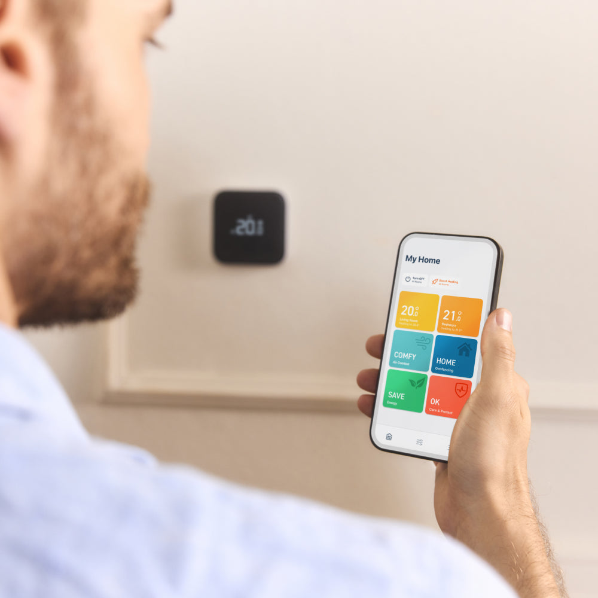

[figure not shown]

[figure not shown]

[figure not shown]

# Wired Smart Thermostat X - Starter Kit

199,99€

Tax included.

**Delivery time: 2-4 working days**

The smart upgrade to your heating: Replace your existing room thermostats yourself in just a few steps and control the temperature with ease using our app or your smart speaker. Save 22% of energy effortlessly – with future-proof technology by the experts.

The Smart Thermostat X is compatible with most boilers and heat pumps (Relay or OpenTherm). You can also use it to control your water-based underfloor heating.

Includes a tado° Bridge X that connects tado° to the internet.

- **Free 10-year warranty* (worth €19.99)**
- **Free fast shipping from €150**
- **30 days free returns**

Why should I equip more radiators?

## Equip more radiators to maximize savings

[figure not shown]

### [Smart Radiator Thermostat X](https://shop.tado.com/en-row/products/smart-radiator-thermostat-x?pr_prod_strat=pinned&pr_rec_id=204f31246&pr_rec_pid=8598491693324&pr_ref_pid=8762124140812&pr_seq=uniform)

- 99,99€

**Why should I equip more radiators?**  
Equip radiators in several rooms of your home to control them individually in one app and set up schedules according to your routines - for maximum comfort and savings.

**Wired Smart Thermostat X - Starter Kit**

199,99€

### Over 5 million active devices

- Europe’s most installed Smart Thermostat brand.

### Compatible with over 95% of systems

- Can be installed with almost any boiler.

### Top App Store rating of 4.6 stars

- Years of top ratings in Apple and Android stores.

### Engineered in Germany

- With 14+ years of smart heating expertise.

### Product details and technical specifications

[figure not shown]

[figure not shown]

[figure not shown]

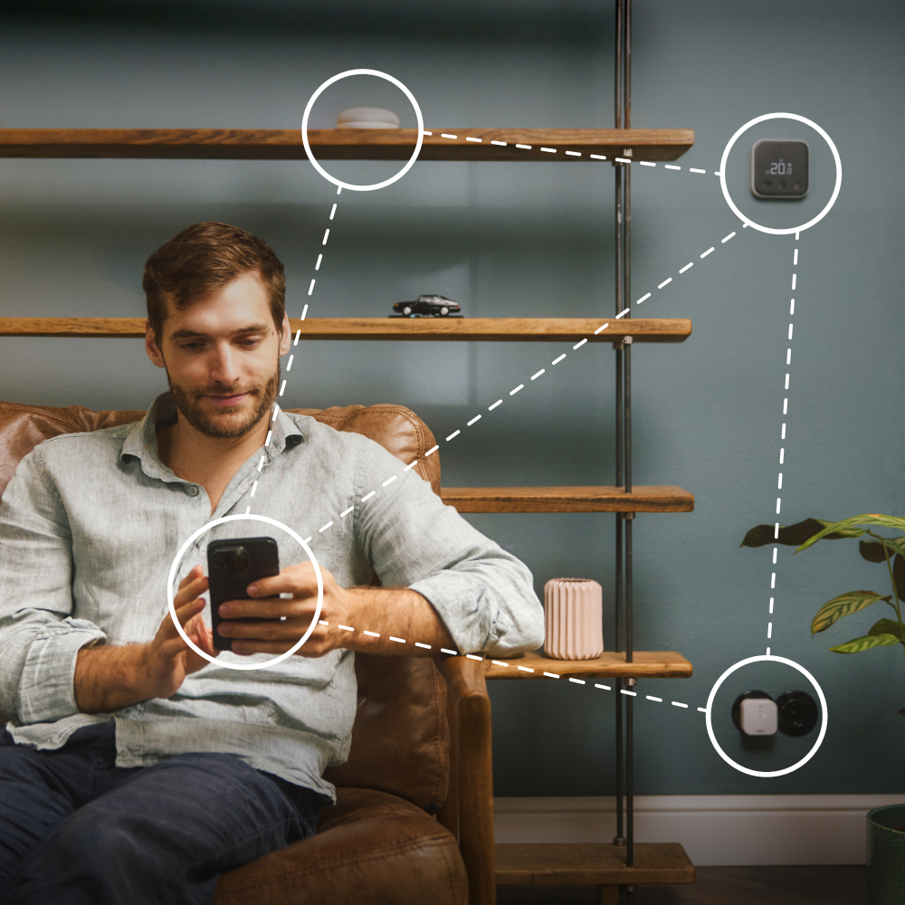

[figure not shown]

- Smart Thermostat X (Wired) for Relay and OpenTherm  
- Bridge X (Thread border router)  
- 3x AAA battery  
- 2x wall mounting screw  
- 2x wall plug  
- 3x sticky pad  
- EU/UK plug

tado° is compatible with all major smart home platforms. In addition, tado° is Matter and Thread-enabled. Learn more [here](https://www.tado.com/en/about/matter-smart-home-devices).

- **Dimensions:** Wired Smart Thermostat X: 104 x 104 x 18 mm; Bridge X: 60 x 60 x 31 mm.
- **Power supply:** Batteries of the Smart Thermostat X: 4.5 VDC 3×AAA (LR03) 1200 mAh; Bridge X: Operating voltage 230 V, energy consumption 0.7 W

The Smart Thermostat X connects to the Internet via the tado° Bridge X. You can plug the Bridge X into any socket and it connects to the Wi-Fi router.  
We recommend one Bridge X per 100m2 to ensure that each Thermostat has a consistent, reliable connection. Other Matter or Thread-enabled devices may serve as range extenders too.  
To install tado°, you need at least iOS 16.4 or Android 9.0.

- **Material:** Smart Thermostat X: PC, ABS; Bridge X: PC.
- **Display:** Display 49 x 30mm LCD, LED backlight; input: 3× mechanical; Bridge X: 4 x LED

Via the app, your smart speaker or with the buttons on the device.

The tado° app, instructions and software are available in English, German, French, Italian, Spanish and Dutch.

## It’s that easy: DIY Installation in under 5 minutes

It couldn’t be easier to install tado° yourself: Our app guides you every step of the way through the installation process.

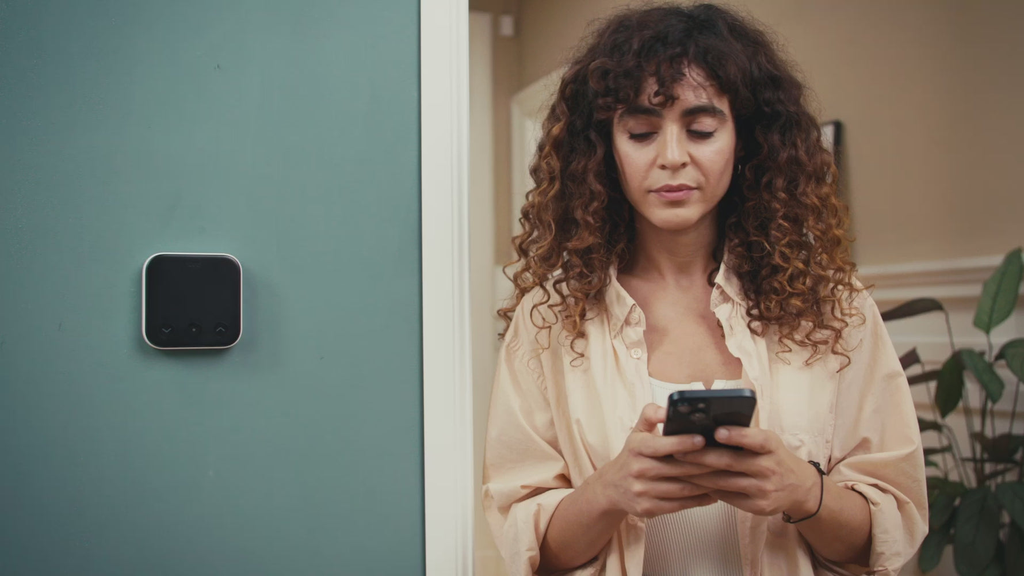

[video not shown]

## Maximise your savings with a full home setup

[figure not shown]

[figure not shown]

### [Smart Radiator Thermostat X](https://shop.tado.com/en-row/products/smart-radiator-thermostat-x)

- Put a Smart Radiator Thermostat in each room for individual control.

  99,99€

[figure not shown]

[figure not shown]

### [Wireless Temperature Sensor X](https://shop.tado.com/en-row/products/wireless-temperature-sensor-x)

- Precise temperature control from the perfect spot in any room.

  99,99€

[figure not shown]

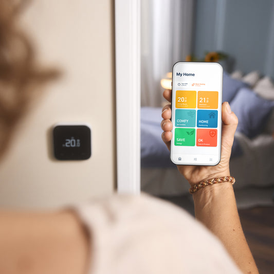

### [Wired Smart Thermostat X](https://shop.tado.com/en-row/products/smart-thermostat-x-wired)

- Add extra Smart Thermostats for individual room control.

  134,99€

## Heating at your fingertips.

The free version of our app comes with every tado° product and is packed with handy features to control and schedule your heating.

Control

Schedule

[figure not shown]

## Control remotely. Wherever you are.

With the tado° app, you can control each room’s temperature from anywhere at any time, whether you are at home, work, or on holiday. Quick Actions let you switch everything off at once or boost warmth instantly.

[Learn more](https://www.tado.com/en/app-services/app)

## Boost savings and comfort with tado° *AI Assist*

Smart automations and dashboards. Only with a tado° AI Assist subscription of €3.99 per month.

[figure not shown]

### Adaptive Heating

- Learns room characteristics and patterns

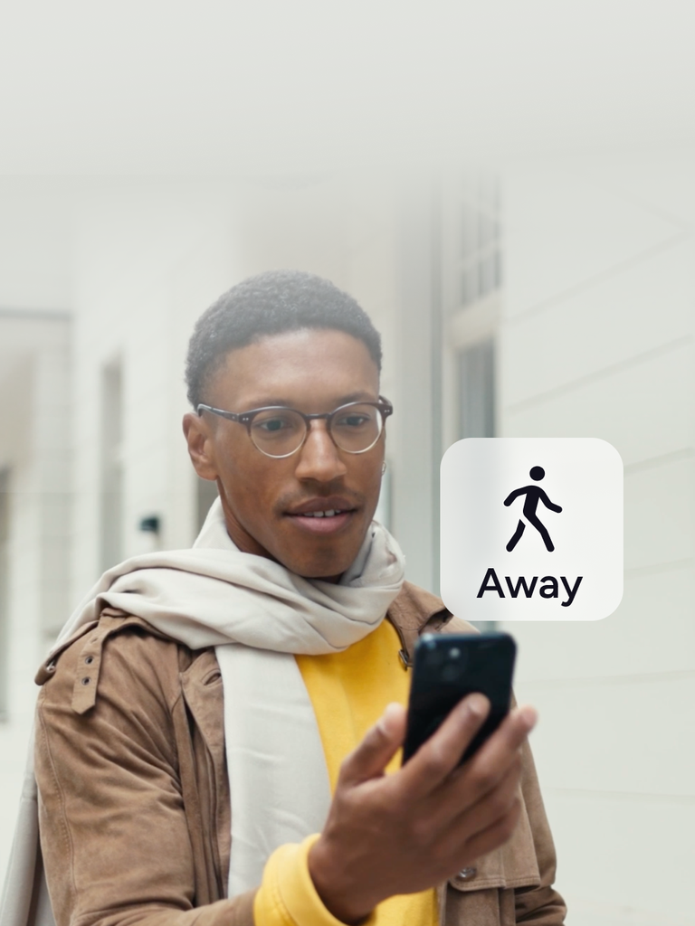

### Geofencing

- Never heat an empty home

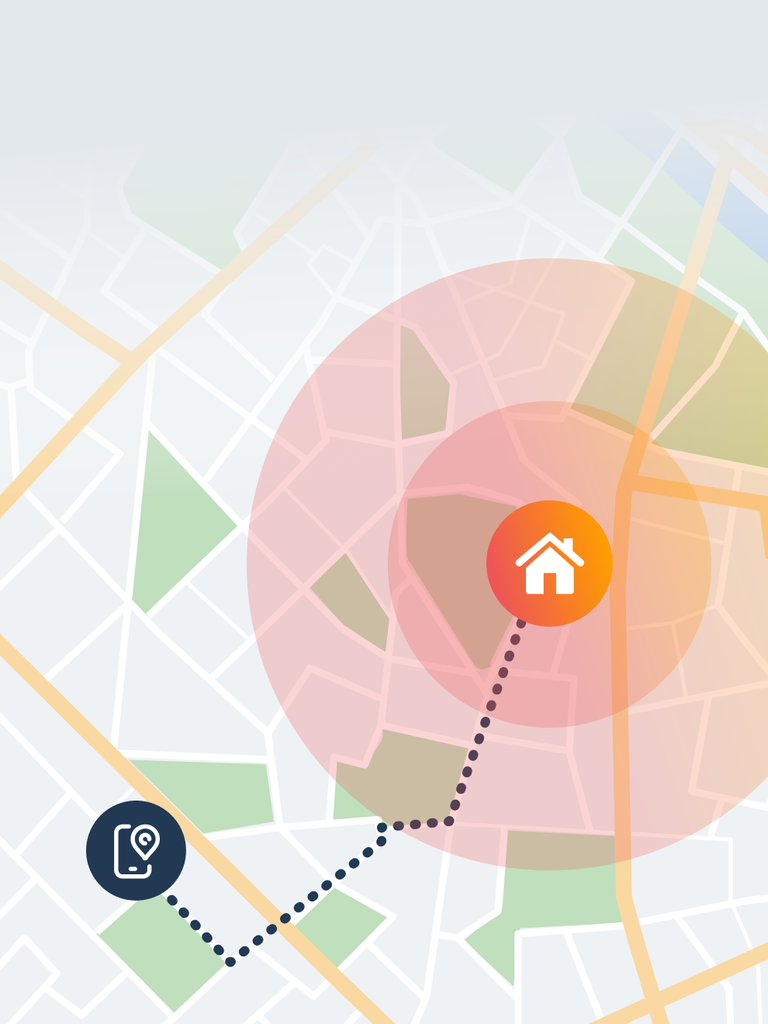

### Pre-heating before arrival

- Always return to a cozy home

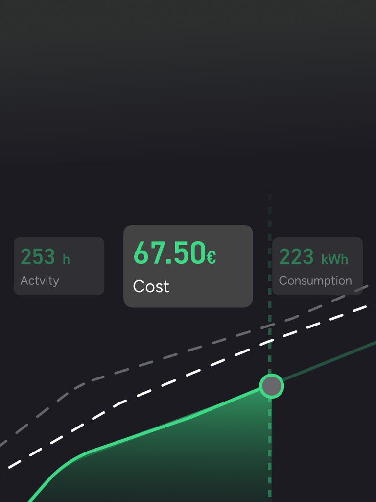

### Energy IQ & smart reports

- Real-time insights on consumption and cost

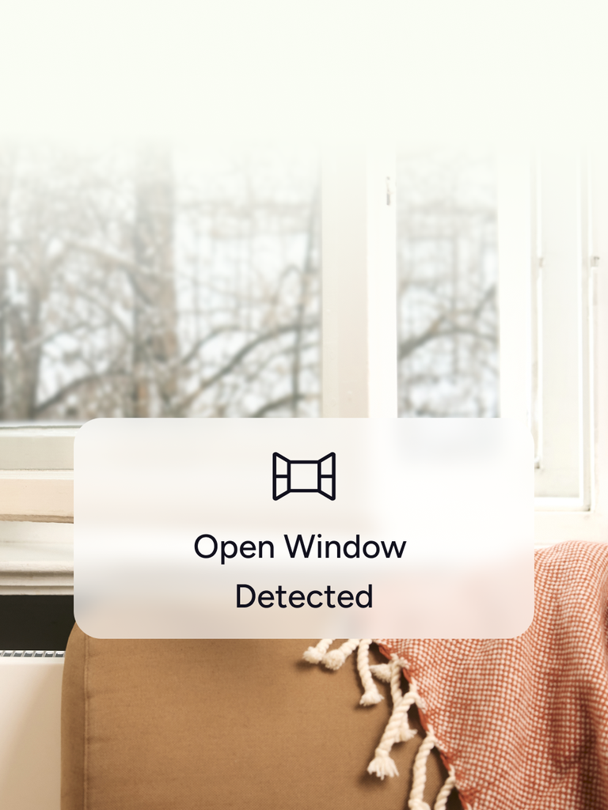

### Advanced Open Window-Detection

- Don't heat the street

[figure not shown]

### Air-quality optimisation

- Monitor & improve your indoor climate

[figure not shown]

### Care & Protect fault detection

- Fix heating issues before they escalate

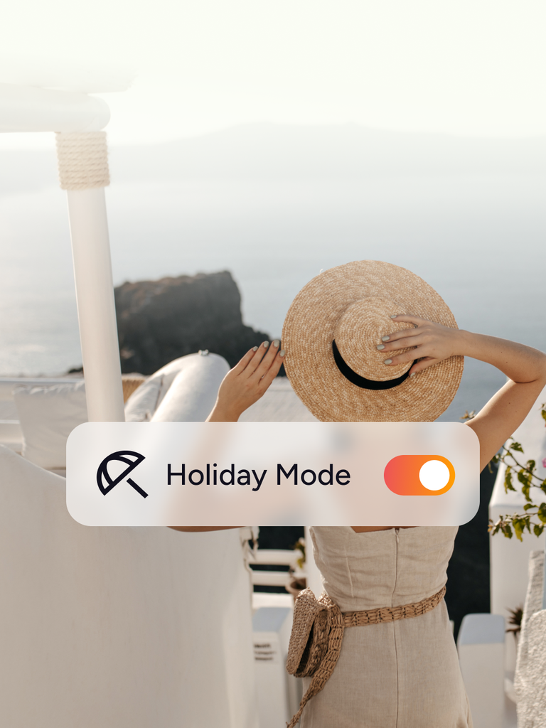

### Holiday Mode

- Relax, tado° handles your heating

[figure not shown]

- Save up to

  55%

### more energy¹

- Save up to

  €485

### a year in heating costs²

- Save up to

  790kg

### in CO2 a year³

### FAQ

The Smart Thermostat X is suitable for boilers that work with Relay or OpenTherm (which is most of them). You can use it to add convenient and smart room control to your water-based underfloor heating and heat pump. You can find out whether tado° is compatible with your heating system in just a few seconds using our [compatibility checker.](https://tado-rwknz.involve.me/productcompatibility-update-fa01a73abe00-copy-ab546a5c19ba)

It’s easy to install it yourself. The app guides you step by step - and is customised to your heating system. You can even install tado° when you’re offline.  
Installing the Bridge X is as easy as plugging it into the socket.

If you already have a Thread Border Router in your home, you won’t need a Bridge X. Otherwise, you can either order it separately from us, or as part of a Starter Kit with your Smart Thermostat X. Please note that the Internet Bridge from the V3+ series is not compatible with tado° X.  
Here you can find a list of Thread Border Routers that work in place of the tado° Bridge X.

If you already have tado° V3+ devices in your home, simply expand them as before with the V3+ Add-ons. The Bridge X and all tado° X products are not compatible with tado° V3+.

You can control all tado° devices easily using Alexa, Google Assistant and Apple Home.

Yes, tado° X is suitable for installation in wet areas.

The Smart Thermostat X is equipped with 3 AAA batteries. tado° reminds you in good time when the battery power is running low and you need to replace the batteries.  
You plug the Bridge X into a socket, which means it doesn’t need batteries.

You can still install tado° if you’re offline. What’s more, Smart Schedules will continue to run even when you’re not connected to the internet because they are saved locally on the device.

Matter ensures a simplified connection between tado° and your smart home, regardless of which products or brands you’re using. Matter-enabled devices will work together reliably and securely now and moving forward into the future.

Thread technology was developed to make networking smart home devices easier: Thread-enabled devices form their own, robust network so that they communicate with each other. The entire network only requires one Thread border router, regardless of the devices you have and the manufacturers they’re from.

## Customer Reviews

4.33 out of 5

Based on 6 reviews

2

4

0

0

0

See all reviews

11/08/2025

Niels

**Super echt een aanrader**

Voor de X variant gegaan. Geen moment spijt van. Eerder wel geprobeerd met google nest, dit werkte niet op de open source /buspoort van onze ATAG ketel (2008).  
Tado daarintegen werkt perfect en was zonder problemen aan te sluiten.  
De thermostaat zelf is vrij basic. Je moet het eigenlijk van de app, en bijbehorend (betaald) abonnement hebben.

*4 van 5 sterren omdat de X lijn nog geen airco aansturings module beschikbaar heeft, wel beschikbaar voor V3.

10/21/2025

Steve Foley

**A 21st Century Central Heating Control system**

I was a bit sceptical to begin with but found it very handy to set different temperatures for different rooms. Also , to be able to control the system via my laptop but also when out and about to be able to use my mobile phone to turn on the heating before I can home and thus have a warm home.

10/21/2025

Ben

**Great thermostat**

Tado has a wide variety of products so for your heating there will be a solution. I bought the thermostat and bridge and wired it opentherm. Installation was super easy. App works decent I am still looking for a setting that when you manually put it on 20 it will go back in away modus after like 2 hours or so. There is however one suggestion I'd like to make. I'd love to have a white front on the thermostat.

08/25/2025

Nietz

**Gut mit Potential**

Im Grundsatz gut - Energieprognosen trotz monatlicher Dateneingabe sehr weit daneben.

01/22/2025

Martin Wächtler

**Funktioniert gut, Installation grösstenteils einfach, optisch m.E. nicht optimal**

Bedienung und Funktion sind super. Auch die Installationsanleitung macht es einem einfach. Lediglich die Grundplatte ist nicht ganz unproblematisch. Die für die Befestigung vorgesehenen Löcher sind offenbar für andere UP-Dosen gedacht, die rechts und links jeweils ein Schraubloch haben. Meine (Schweizer) UP-Dosen haben vier Löcher an den Ecken, was ein bisschen Nacharbeit erfordert.  
Die Optik ist sicherlich gewöhnungsbedürftig, die vorher installierten Feller Thermostate waren weiss, flach und unauffällig.

*[Terms & conditions](https://www.tado.com/en/customer-services/extended-warranty) apply.  
*¹ Up to 55% more savings is based on internal modelling comparing the use of tado° AI Assist vs the free tado° app. Actual savings depend on household characteristics, usage patterns and external factors.*  
² *Actual savings depend on household energy use and may vary. €485 annual savings reflect 22% of the EU average gas heating bill (€2,208) as reported by Eurostat for 2024, based on our user base average. Results may differ.*  
³ *Actual savings depend on household energy use and regional factors. CO₂ savings are based on an average EU household gas heating consumption of approximately 20,000 kWh per year and an emission factor of 0.18 kg CO₂/kWh for natural gas combustion, resulting in estimated savings of up to 790 kg CO₂ annually for a 22% reduction. Data based on Eurostat Natural Gas Price Statistics 2024 and European Heat Pump Association reports. Individual results may vary.*

*The shipping of your order is free of charge within the EU from an order value of €150,00. For orders under €150,00, the shipping costs are €4.99.*